# QPalette Class

The QPalette class contains color groups for each widget state. More...

| Header: | `#include <QPalette>` |
| --- | --- |
| CMake: | `find_package(Qt6 REQUIRED COMPONENTS Gui)` `target_link_libraries(mytarget PRIVATE Qt6::Gui)` |
| qmake: | `QT += gui` |

- [List of all members, including inherited members](https://doc.qt.io/qt-6.9/qpalette-members.html)
- [Deprecated members](https://doc.qt.io/qt-6.9/qpalette-obsolete.html)
- QPalette is part of Implicitly Shared Classes.

## Public Types

| enum | **ColorGroup** { Disabled, Active, Inactive, Normal } |
| --- | --- |
| enum | **ColorRole** { Window, WindowText, Base, AlternateBase, ToolTipBase, …, NoRole } |

## Public Functions

[output not shown]

## Related Non-Members

| QDataStream & | **operator<<**(QDataStream &*s*, const QPalette &*p*) |
| --- | --- |
| QDataStream & | **operator>>**(QDataStream &*s*, QPalette &*p*) |

## Detailed Description

A palette consists of three color groups: *Active*, *Disabled*, and *Inactive*. All widgets in Qt contain a palette and use their palette to draw themselves. This makes the user interface easily configurable and easier to keep consistent.

If you create a new widget we strongly recommend that you use the colors in the palette rather than hard-coding specific colors.

The color groups:

- The Active group is used for the window that has keyboard focus.
- The Inactive group is used for other windows.
- The Disabled group is used for widgets (not windows) that are disabled for some reason.

Both active and inactive windows can contain disabled widgets. (Disabled widgets are often called *inaccessible* or *grayed out*.)

In most styles, Active and Inactive look the same.

Colors and brushes can be set for particular roles in any of a palette's color groups with setColor() and setBrush(). A color group contains a group of colors used by widgets for drawing themselves. We recommend that widgets use color group roles from the palette such as "foreground" and "base" rather than literal colors like "red" or "turquoise". The color roles are enumerated and defined in the ColorRole documentation.

We strongly recommend that you use the default palette of the current style (returned by QGuiApplication::palette()) and modify that as necessary. This is done by Qt's widgets when they are drawn.

To modify a color group you call the functions setColor() and setBrush(), depending on whether you want a pure color or a pixmap pattern.

There are also corresponding color() and brush() getters, and a commonly used convenience function to get the ColorRole for the current ColorGroup: window(), windowText(), base(), etc.

You can copy a palette using the copy constructor and test to see if two palettes are *identical* using isCopyOf().

QPalette is optimized by the use of implicit sharing, so it is very efficient to pass QPalette objects as arguments.

**Warning:** Some styles do not use the palette for all drawing, for instance, if they make use of native theme engines. This is the case for both the Windows Vista and the macOS styles.

**See also** QApplication::setPalette(), QWidget::setPalette(), and QColor.

## Member Type Documentation

### enum QPalette::ColorGroup

| Constant | Value | Description |
| --- | --- | --- |
| `QPalette::Disabled` | `1` |  |
| `QPalette::Active` | `0` |  |
| `QPalette::Inactive` | `2` |  |
| `QPalette::Normal` | `Active` | synonym for Active |

### enum QPalette::ColorRole

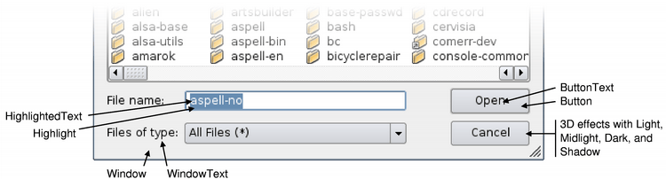

The ColorRole enum defines the different symbolic color roles used in current GUIs.

The central roles are:

[output not shown]

There are some color roles used mostly for 3D bevel and shadow effects. All of these are normally derived from `Window`, and used in ways that depend on that relationship. For example, buttons depend on it to make the bevels look attractive, and Motif scroll bars depend on `Mid` to be slightly different from `Window`.

| Constant | Value | Description |
| --- | --- | --- |
| `QPalette::Light` | `2` | Lighter than `Button` color. |
| `QPalette::Midlight` | `3` | Between `Button` and `Light`. |
| `QPalette::Dark` | `4` | Darker than `Button`. |
| `QPalette::Mid` | `5` | Between `Button` and `Dark`. |
| `QPalette::Shadow` | `11` | A very dark color. By default, the shadow color is Qt::black. |

[output not shown]

There are two color roles related to hyperlinks:

| Constant | Value | Description |
| --- | --- | --- |
| `QPalette::Link` | `14` | A text color used for unvisited hyperlinks. By default, the link color is Qt::blue. |
| `QPalette::LinkVisited` | `15` | A text color used for already visited hyperlinks. By default, the linkvisited color is Qt::magenta. |

Note that we do not use the `Link` and `LinkVisited` roles when rendering rich text in Qt, and that we recommend that you use CSS and the QTextDocument::setDefaultStyleSheet() function to alter the appearance of links. For example:

```
    QTextBrowser browser;
    QColor linkColor(Qt::red);
    QString sheet = QString::fromLatin1("a { text-decoration: underline; color: %1 }").arg(linkColor.name());
    browser.document()->setDefaultStyleSheet(sheet);
```

| Constant | Value | Description |
| --- | --- | --- |
| `QPalette::NoRole` | `17` | No role; this special role is often used to indicate that a role has not been assigned. |

## Member Function Documentation

### QPalette::QPalette()

Constructs an empty palette object with no color roles set.

When used as the palette of a QWidget the colors are resolved as described by QWidget::setPalette().

**See also** QApplication::setPalette() and QApplication::palette().

### QPalette::QPalette(Qt::GlobalColor *button*)

Constructs a palette from the *button* color. The other colors are automatically calculated, based on this color. `Window` will be the button color as well.

### QPalette::QPalette(const QColor &*button*)

Constructs a palette from the *button* color. The other colors are automatically calculated, based on this color. `Window` will be the button color as well.

### QPalette::QPalette(const QColor &*button*, const QColor &*window*)

Constructs a palette from a *button* color and a *window*. The other colors are automatically calculated, based on these colors.

### QPalette::QPalette(const QBrush &*windowText*, const QBrush &*button*, const QBrush &*light*, const QBrush &*dark*, const QBrush &*mid*, const QBrush &*text*, const QBrush &*bright_text*, const QBrush &*base*, const QBrush &*window*)

Constructs a palette. You can pass either brushes, pixmaps or plain colors for *windowText*, *button*, *light*, *dark*, *mid*, *text*, *bright_text*, *base* and *window*.

**See also** QBrush.

### QPalette::QPalette(const QPalette &*p*)

Constructs a copy of *p*.

This constructor is fast thanks to implicit sharing.

### `[noexcept]` QPalette::QPalette(QPalette &&*other*)

Move-constructs a QPalette instance, making it point at the same object that *other* was pointing to.

After being moved from, you can only assign to or destroy *other*. Any other operation will result in undefined behavior.

### `[noexcept]` QPalette::~QPalette()

Destroys the palette.

### `[since 6.6]` const QBrush &QPalette::accent() const

Returns the accent brush of the current color group.

This function was introduced in Qt 6.6.

**See also** ColorRole and brush().

### const QBrush &QPalette::alternateBase() const

Returns the alternate base brush of the current color group.

**See also** ColorRole and brush().

### const QBrush &QPalette::base() const

Returns the base brush of the current color group.

**See also** ColorRole and brush().

### const QBrush &QPalette::brightText() const

Returns the bright text foreground brush of the current color group.

**See also** ColorRole and brush().

### const QBrush &QPalette::brush(QPalette::ColorGroup *group*, QPalette::ColorRole *role*) const

Returns the brush in the specified color *group*, used for the given color *role*.

**See also** color(), setBrush(), and ColorRole.

### const QBrush &QPalette::brush(QPalette::ColorRole *role*) const

Returns the brush that has been set for the given color *role* in the current ColorGroup.

This is an overloaded function.

**See also** color(), setBrush(), and ColorRole.

### const QBrush &QPalette::button() const

Returns the button brush of the current color group.

**See also** ColorRole and brush().

### const QBrush &QPalette::buttonText() const

Returns the button text foreground brush of the current color group.

**See also** ColorRole and brush().

### qint64 QPalette::cacheKey() const

Returns a number that identifies the contents of this QPalette object. Distinct QPalette objects can have the same key if they refer to the same contents.

The cacheKey() will change when the palette is altered.

### const QColor &QPalette::color(QPalette::ColorGroup *group*, QPalette::ColorRole *role*) const

Returns the color in the specified color *group*, used for the given color *role*.

**See also** brush(), setColor(), and ColorRole.

### const QColor &QPalette::color(QPalette::ColorRole *role*) const

Returns the color that has been set for the given color *role* in the current ColorGroup.

This is an overloaded function.

**See also** brush() and ColorRole.

### QPalette::ColorGroup QPalette::currentColorGroup() const

Returns the palette's current color group.

**See also** setCurrentColorGroup().

### const QBrush &QPalette::dark() const

Returns the dark brush of the current color group.

**See also** ColorRole and brush().

### const QBrush &QPalette::highlight() const

Returns the highlight brush of the current color group.

**See also** ColorRole and brush().

### const QBrush &QPalette::highlightedText() const

Returns the highlighted text brush of the current color group.

**See also** ColorRole and brush().

### bool QPalette::isBrushSet(QPalette::ColorGroup *cg*, QPalette::ColorRole *cr*) const

Returns `true` if the ColorGroup *cg* and ColorRole *cr* has been set previously on this palette; otherwise returns `false`.

The ColorGroup *cg* should be less than QPalette::NColorGroups, but you can use QPalette::Current. In this case, the previously set current color group will be used.

The ColorRole *cr* should be less than QPalette::NColorRoles.

**See also** setBrush() and currentColorGroup().

### bool QPalette::isCopyOf(const QPalette &*p*) const

Returns `true` if this palette and *p* are copies of each other, i.e. one of them was created as a copy of the other and neither was subsequently modified; otherwise returns `false`. This is much stricter than equality.

**See also** operator=() and operator==().

### bool QPalette::isEqual(QPalette::ColorGroup *cg1*, QPalette::ColorGroup *cg2*) const

Returns `true` (usually quickly) if color group *cg1* is equal to *cg2*; otherwise returns `false`.

### const QBrush &QPalette::light() const

Returns the light brush of the current color group.

**See also** ColorRole and brush().

### const QBrush &QPalette::link() const

Returns the unvisited link text brush of the current color group.

**See also** ColorRole and brush().

### const QBrush &QPalette::linkVisited() const

Returns the visited link text brush of the current color group.

**See also** ColorRole and brush().

### const QBrush &QPalette::mid() const

Returns the mid brush of the current color group.

**See also** ColorRole and brush().

### const QBrush &QPalette::midlight() const

Returns the midlight brush of the current color group.

**See also** ColorRole and brush().

### const QBrush &QPalette::placeholderText() const

Returns the placeholder text brush of the current color group.

**Note:** Before Qt 5.12, the placeholder text color was hard-coded as QPalette::text().color() with an alpha of 128 applied. In Qt 6, it is an independent color.

**See also** ColorRole and brush().

### QPalette QPalette::resolve(const QPalette &*other*) const

Returns a new QPalette that is a union of this instance and *other*. Color roles set in this instance take precedence. Roles that are not set in this instance will be taken from *other*.

**See also** isBrushSet.

### void QPalette::setBrush(QPalette::ColorRole *role*, const QBrush &*brush*)

Sets the brush for the given color *role* to the specified *brush* for all groups in the palette.

**See also** brush(), setColor(), and ColorRole.

### void QPalette::setBrush(QPalette::ColorGroup *group*, QPalette::ColorRole *role*, const QBrush &*brush*)

Sets the brush in the specified color *group*, used for the given color *role*, to *brush*.

This is an overloaded function.

**See also** brush(), setColor(), and ColorRole.

### void QPalette::setColor(QPalette::ColorGroup *group*, QPalette::ColorRole *role*, const QColor &*color*)

Sets the color in the specified color *group*, used for the given color *role*, to the specified solid *color*.

**See also** setBrush(), color(), and ColorRole.

### void QPalette::setColor(QPalette::ColorRole *role*, const QColor &*color*)

Sets the color used for the given color *role*, in all color groups, to the specified solid *color*.

This is an overloaded function.

**See also** brush(), setColor(), and ColorRole.

### void QPalette::setColorGroup(QPalette::ColorGroup *cg*, const QBrush &*windowText*, const QBrush &*button*, const QBrush &*light*, const QBrush &*dark*, const QBrush &*mid*, const QBrush &*text*, const QBrush &*bright_text*, const QBrush &*base*, const QBrush &*window*)

Sets a the group at *cg*. You can pass either brushes, pixmaps or plain colors for *windowText*, *button*, *light*, *dark*, *mid*, *text*, *bright_text*, *base* and *window*.

**See also** QBrush.

### void QPalette::setCurrentColorGroup(QPalette::ColorGroup *cg*)

Set the palette's current color group to *cg*.

**See also** currentColorGroup().

### const QBrush &QPalette::shadow() const

Returns the shadow brush of the current color group.

**See also** ColorRole and brush().

### `[noexcept]` void QPalette::swap(QPalette &*other*)

Swaps this palette instance with *other*. This operation is very fast and never fails.

### const QBrush &QPalette::text() const

Returns the text foreground brush of the current color group.

**See also** ColorRole and brush().

### const QBrush &QPalette::toolTipBase() const

Returns the tool tip base brush of the current color group. This brush is used by QToolTip and QWhatsThis.

**Note:** Tool tips use the Inactive color group of QPalette, because tool tips are not active windows.

**See also** ColorRole and brush().

### const QBrush &QPalette::toolTipText() const

Returns the tool tip text brush of the current color group. This brush is used by QToolTip and QWhatsThis.

**Note:** Tool tips use the Inactive color group of QPalette, because tool tips are not active windows.

**See also** ColorRole and brush().

### const QBrush &QPalette::window() const

Returns the window (general background) brush of the current color group.

**See also** ColorRole and brush().

### const QBrush &QPalette::windowText() const

Returns the window text (general foreground) brush of the current color group.

**See also** ColorRole and brush().

### QVariant QPalette::operator QVariant() const

Returns the palette as a QVariant

### bool QPalette::operator!=(const QPalette &*p*) const

Returns `true` (slowly) if this palette is different from *p*; otherwise returns `false` (usually quickly).

**Note:** The current ColorGroup is not taken into account when comparing palettes

**See also** operator==().

### `[noexcept]` QPalette &QPalette::operator=(QPalette &&*other*)

Move-assigns *other* to this QPalette instance.

### QPalette &QPalette::operator=(const QPalette &*p*)

Assigns *p* to this palette and returns a reference to this palette.

This operation is fast thanks to implicit sharing.

### `[since 6.6]` bool QPalette::operator==(const QPalette &*p*) const

Returns `true` (usually quickly) if this palette is equal to *p*; otherwise returns `false` (slowly).

**Note:** The following is not taken into account when comparing palettes:

- the `current` ColorGroup
- ColorRole NoRole

This function was introduced in Qt 6.6.

**See also** operator!=().

## Related Non-Members

### QDataStream &operator<<(QDataStream &*s*, const QPalette &*p*)

Writes the palette, *p* to the stream *s* and returns a reference to the stream.

**See also** Format of the QDataStream operators.

### QDataStream &operator>>(QDataStream &*s*, QPalette &*p*)

Reads a palette from the stream, *s* into the palette *p*, and returns a reference to the stream.

**See also** Format of the QDataStream operators.

© The Qt Company Ltd  
Licensed under the GNU Free Documentation License, Version 1.3.  
https://doc.qt.io/qt-6.9/qpalette.html